# Testing drake

@dataknut

4/18/2019

# Drake

```r
# readd the data object

dt <- readd(data)

t <- summary(dt)

kableExtra::kable(t, caption = "Data summary")
```

Data summary

Site_Code

POC_Code

Nwk_Code

Gen_Code

Fuel_Code

Tech_Code

Trading_date

Time_Period

[output not shown]

[output not shown]

[output not shown]

rDateTime

Length:106500

Length:106500

Length:106500

Length:106500

Length:106500

Length:106500

Min. :2018-06-01

TP1 : 2130

Min. : 0

Length:106500

Min. :2018-06-01

Min. :2018-06-01 00:15:00

Class :character

Class :character

Class :character

Class :character

Class :character

Class :character

1st Qu.:2018-06-08

TP2 : 2130

1st Qu.: 5376

Class1:hms

1st Qu.:2018-06-08

1st Qu.:2018-06-08 12:07:30

Mode :character

Mode :character

Mode :character

Mode :character

Mode :character

Mode :character

Median :2018-06-15

TP3 : 2130

Median : 17757

Class2:difftime

Median :2018-06-15

Median :2018-06-16 00:00:00

NA

NA

NA

NA

NA

NA

Mean :2018-06-15

TP4 : 2130

Mean : 36137

Mode :numeric

Mean :2018-06-15

Mean :2018-06-16 00:00:00

NA

NA

NA

NA

NA

NA

3rd Qu.:2018-06-23

TP5 : 2130

3rd Qu.: 46740

NA

3rd Qu.:2018-06-23

3rd Qu.:2018-06-23 11:52:30

NA

NA

NA

NA

NA

NA

Max. :2018-06-30

TP6 : 2130

Max. :397494

NA

Max. :2018-06-30

Max. :2018-06-30 23:45:00

NA

NA

NA

NA

NA

NA

NA

(Other):93720

NA’s :4260

NA

NA

NA’s :4260

Now re `readd` a plot we made using the data. Note that we don’t build the plot in the .Rmd file (via knitr) we just bring back the object from wherever drake stored it.

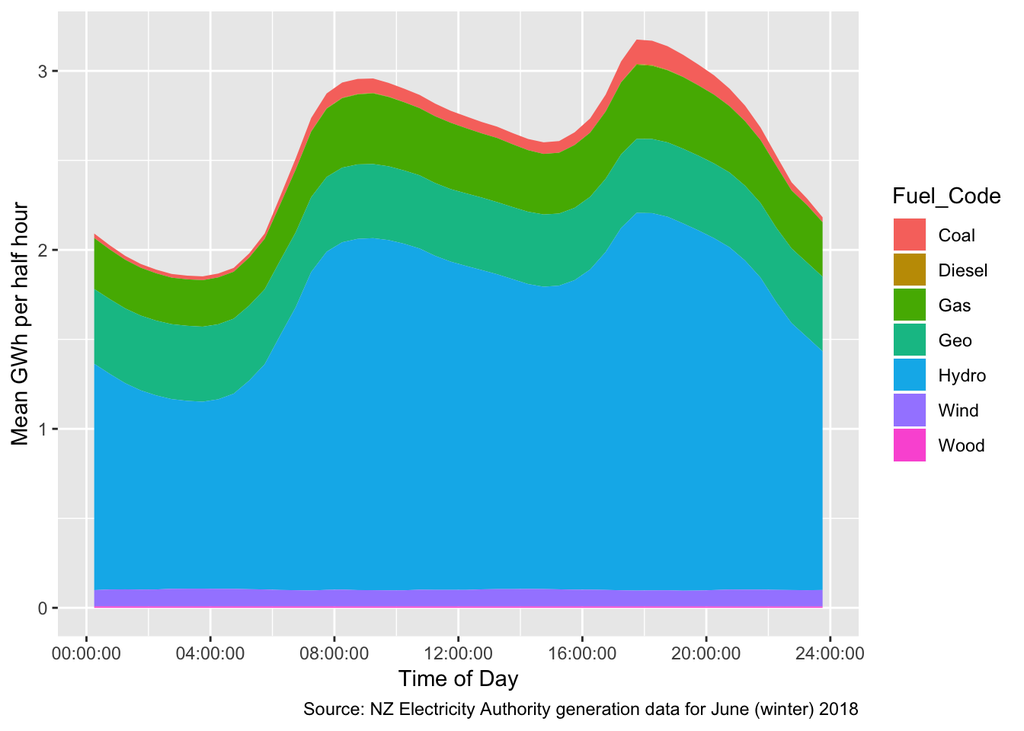

```r
p <- readd(profilePlot) # we don't need to create the p but this would let us add stuff

p
```

This is all really rather cool…

But the very cool bit is that if we make some changes to the code that makes the plot, when we re-make our drake plan, drake will only re-build the plot and the report. It will not go and get the data again - it knows nothing changed.